# Rapport : Dimensionnement d'un Buffer Réseau

## 3. Question 1 : Chaîne de Markov

### Description de la Chaîne

Pour **K = 5**, la chaîne de Markov possède **6 états** (0 à 5) représentant le nombre de paquets dans le buffer.

Le graphe suivant montre la structure de la chaîne de Markov avec les transitions possibles entre les états :

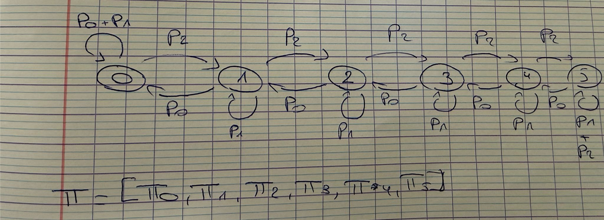

**Commentaire :** Le graphe montre les 6 états (0 à 5) et les transitions possibles. Les arcs sont étiquetés avec les probabilités de transition. On observe que :

- L'état 0 ne peut que recevoir des paquets (pas de service)
- Les états intermédiaires peuvent recevoir ou perdre des paquets
- L'état 5 (buffer plein) peut perdre des paquets lors d'arrivées

```python
# Cette cellule est maintenant vide car l'image est intégrée directement dans la cellule markdown précédente
```

## 4. Question 2 : Distribution de Probabilité Stationnaire π(K)

### Calcul de la Distribution Stationnaire

La distribution stationnaire $\pi = [\pi_0, \pi_1, \ldots, \pi_K]$ est obtenue par la formule analytique :

avec la contrainte de normalisation :

$$\sum_{i=0}^{K} \pi_i = 1$$

Cette distribution représente les **probabilités d'équilibre** de chaque état du système à long terme, c'est-à-dire :

$$\pi_i = \lim_{n \to \infty} \mathbb{P}(X_n = i)$$

### Visualisation pour K ∈ {2, 5, 10, 15, 80}

Le graphique suivant montre la distribution stationnaire pour différentes valeurs de K avec la configuration initiale (p₀=0.4, p₁=0.2, p₂=0.4) :

[figure not shown]

```python
# Configuration et imports
import numpy as np
import matplotlib.pyplot as plt
import pandas as pd
from IPython.display import display, HTML
import warnings
warnings.filterwarnings('ignore')

# Chargement des fonctions du projet
exec(open('buffer_dimensionnement.py').read())

# Paramètres initiaux
p0, p1, p2 = 0.4, 0.2, 0.4
valeurs_K = [2, 5, 10, 15, 80]

print("Bibliothèques et fonctions chargées avec succès !")
```